NetGLM by NetSimR

# GLM Report

Generated 20 November 2026, 13:55

## Key results

claim_count ~ offset(log(exposure)) + ns(age, df = 4) + region + vehicle + log(vehicle_value), poisson family with the log link.

Observations

8,000

2,000 rows held out for testing

Parameters

11

AIC

5,245.163

Deviance explained

1.58%

Gini

0.108

Test rows; training 0.137

Deviance per row

0.4896

Test rows; training 0.4637

## Data and model

Data

**Source**

Example: motor policies

**Rows**

10,000

**Held out for testing**

2,000 rows (seed 1)

Model

**Response**

claim_count

**Family**

poisson

**Link**

log

**Offset**

log(exposure)

**Weights**

None

**Terms**

ns(age, df = 4) + region + vehicle + log(vehicle_value)

## Coefficients

| Term | Estimate | Std. error | p-value | Relativity |
| --- | --- | --- | --- | --- |
| (Intercept) | -2.8927 | 0.7829 | 0.00022 | 0.05543 |
| ns(age, df = 4)1 | -0.57334 | 0.1613 | 0.000378 | 0.5636 |
| ns(age, df = 4)2 | -0.63435 | 0.1894 | 0.000812 | 0.5303 |
| ns(age, df = 4)3 | -1.9014 | 0.3849 | 7.84e-07 | 0.1494 |
| ns(age, df = 4)4 | -0.32898 | 0.3064 | 0.283 | 0.7197 |
| regionNorth | 0.19741 | 0.09373 | 0.0352 | 1.218 |
| regionSouth | -0.07262 | 0.1036 | 0.484 | 0.93 |
| regionWest | -0.11427 | 0.1108 | 0.303 | 0.892 |
| vehiclemotorcycle | 0.5402 | 0.1156 | 2.98e-06 | 1.716 |
| vehiclevan | 0.14893 | 0.09377 | 0.112 | 1.161 |
| log(vehicle_value) | 0.14345 | 0.07904 | 0.0695 | 1.154 |

Relativity: exp(estimate).

## Rate table

Base rate 0.13598: a policy's prediction is the base rate times its relativity in every rating factor (times its exposure).

### age

| Value | Rows | Relativity |
| --- | --- | --- |
| 18 | 44 | 1.993 |
| 20 | 58 | 1.729 |
| 23 | 107 | 1.408 |
| 25 | 102 | 1.241 |
| 27 | 101 | 1.108 |
| 30 | 134 | 0.9633 |
| 32 | 155 | 0.9008 |
| 34 | 170 | 0.8636 |
| 36 | 184 | 0.8519 |
| 39 | 174 | 0.8797 |
| 41 | 201 | 0.917 |
| 43 | 223 | 0.9578 |
| 46 | 194 | 1 |
| 48 | 179 | 0.9996 |
| 50 | 209 | 0.9786 |
| 53 | 200 | 0.9258 |
| 55 | 177 | 0.8873 |
| 57 | 165 | 0.8536 |
| 60 | 131 | 0.8159 |
| 62 | 114 | 0.7981 |
| 64 | 106 | 0.7852 |
| 67 | 88 | 0.7739 |
| 69 | 62 | 0.771 |
| 71 | 54 | 0.7712 |
| 73 | 49 | 0.7741 |
| 76 | 28 | 0.7829 |
| 78 | 28 | 0.7911 |
| 80 | 26 | 0.8008 |
| 83 | 10 | 0.8175 |
| 85 | 13 | 0.8294 |

Terms: ns(age, df = 4). Base: 46. 30 of its 68 values are shown.

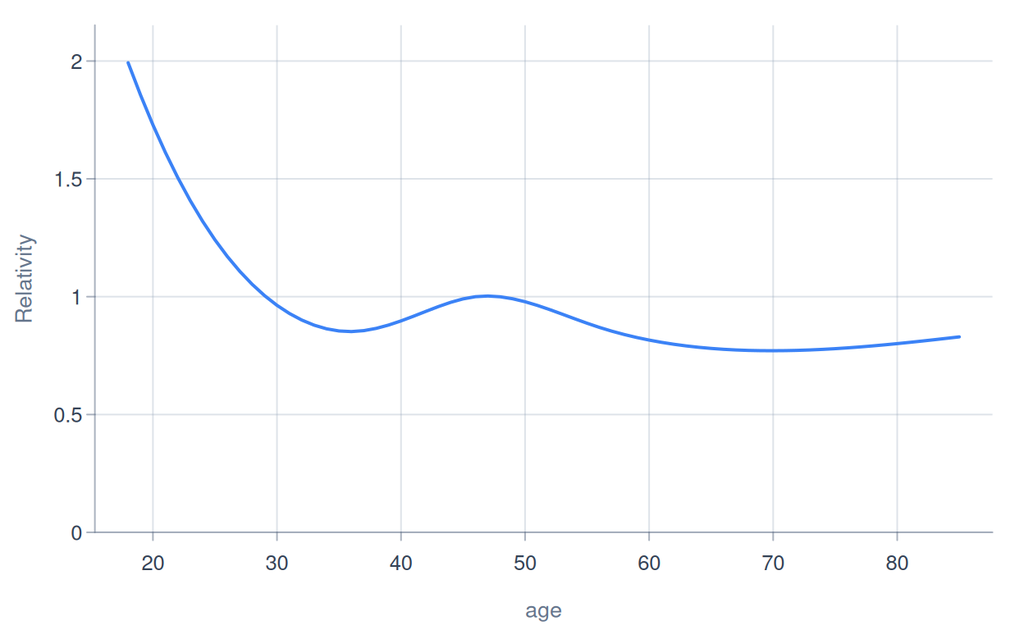

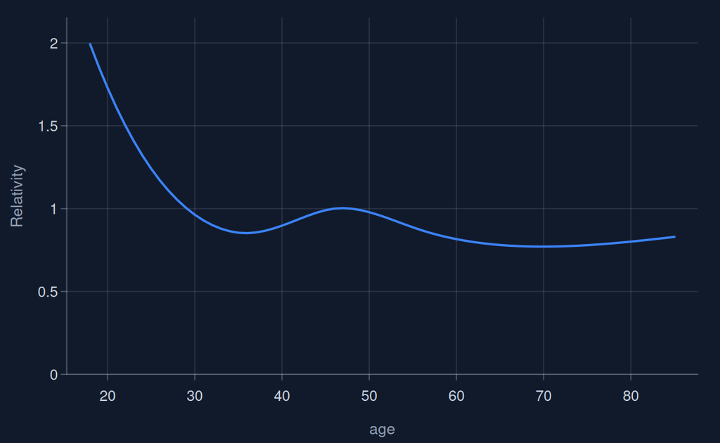

### region

| Value | Rows | Relativity |
| --- | --- | --- |
| East | 1,979 | 0.8209 |
| North | 2,368 | 1 |
| South | 2,012 | 0.7634 |
| West | 1,641 | 0.7322 |

Terms: region. Base: North.

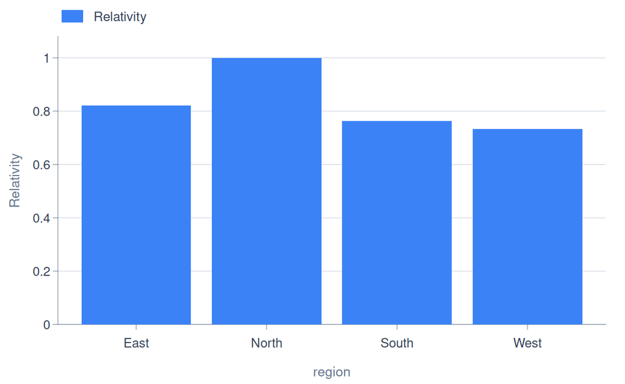

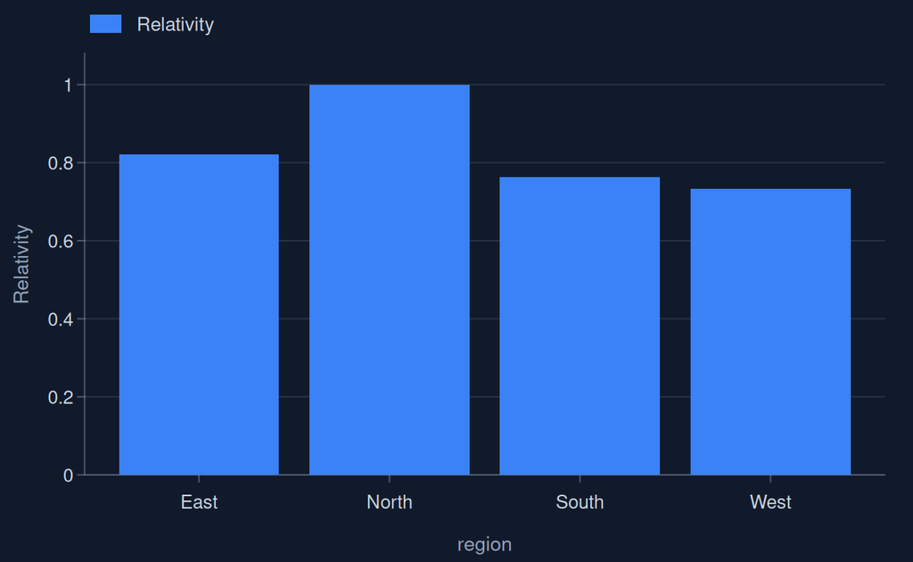

### vehicle

| Value | Rows | Relativity |
| --- | --- | --- |
| car | 5,789 | 1 |
| motorcycle | 762 | 1.716 |
| van | 1,449 | 1.161 |

Terms: vehicle. Base: car.

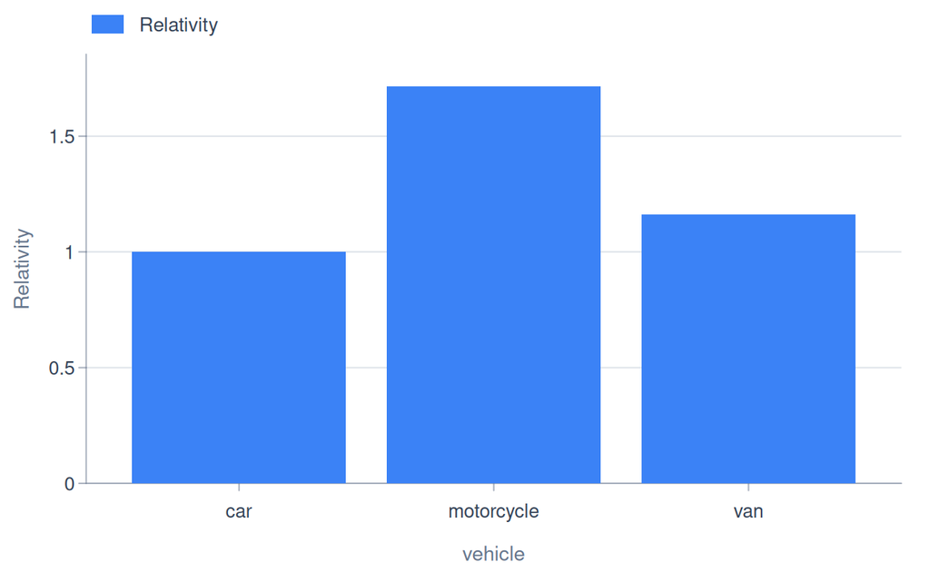

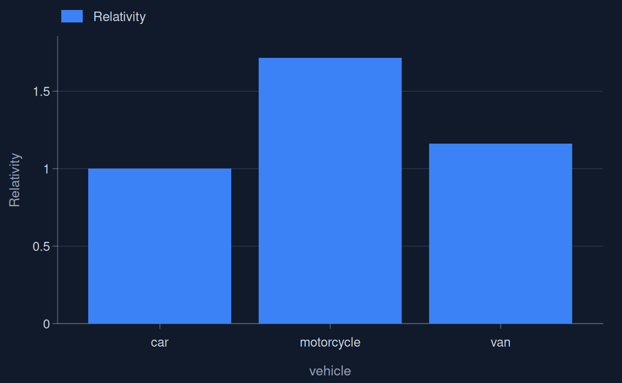

### vehicle_value

| Value | Rows | Relativity |
| --- | --- | --- |
| 2200 | — | 0.7516 |
| 6140 | — | 0.8709 |
| 7600 | — | 0.8979 |
| 8400 | — | 0.9109 |
| 9300 | — | 0.9243 |
| 10000 | — | 0.934 |
| 10600 | — | 0.9418 |
| 11300 | — | 0.9505 |
| 11900 | — | 0.9576 |
| 12700 | — | 0.9665 |
| 13300 | — | 0.973 |
| 14000 | — | 0.9802 |
| 14600 | — | 0.9861 |
| 15100 | — | 0.9908 |
| 15900 | — | 0.9982 |
| 16500 | — | 1.004 |
| 17500 | — | 1.012 |
| 18200 | — | 1.018 |
| 18900 | — | 1.023 |
| 19900 | — | 1.031 |
| 20700 | — | 1.037 |
| 21800 | — | 1.044 |
| 22900 | — | 1.052 |
| 24600 | — | 1.063 |
| 26000 | — | 1.071 |
| 27600 | — | 1.08 |
| 30200 | — | 1.094 |
| 32900 | — | 1.108 |
| 40900 | — | 1.143 |
| 93100 | — | 1.286 |

Terms: log(vehicle_value). Base: 16100. 30 of its 100 values are shown.

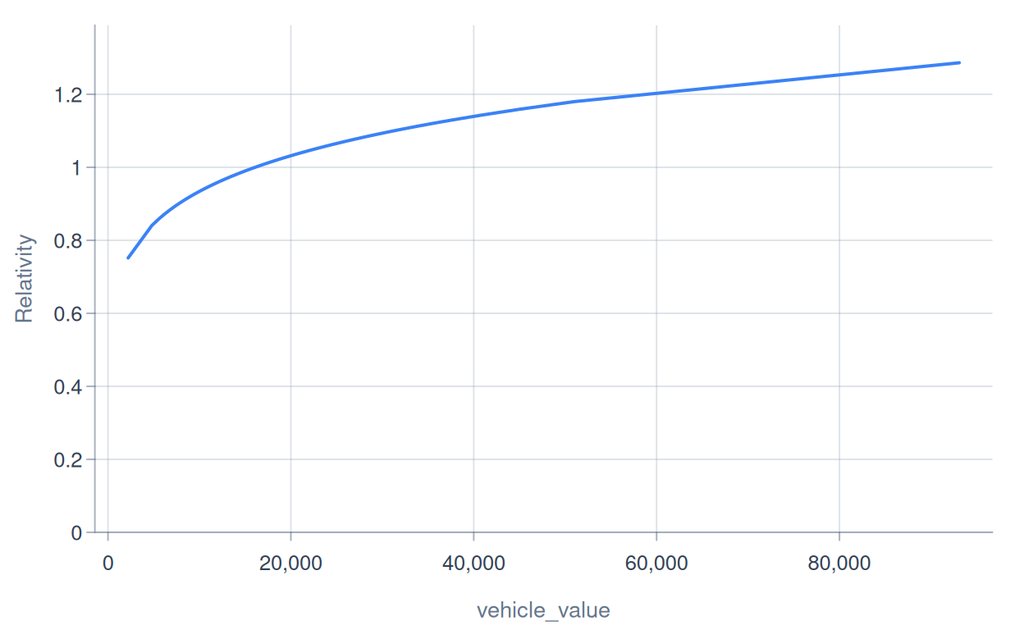

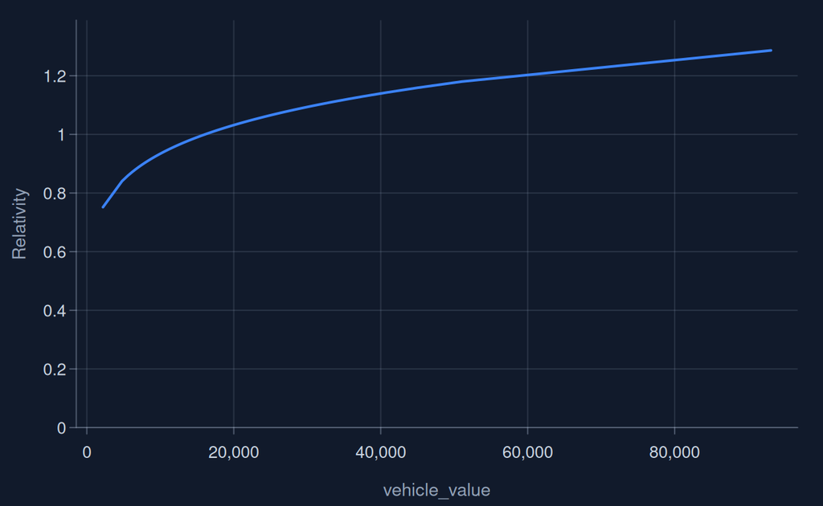

## Validation

On the test rows.

### Lift chart

The rows sorted by their predicted rate, in bands of about the same exposure: the actual line should rise steeply and the predicted line follow it.

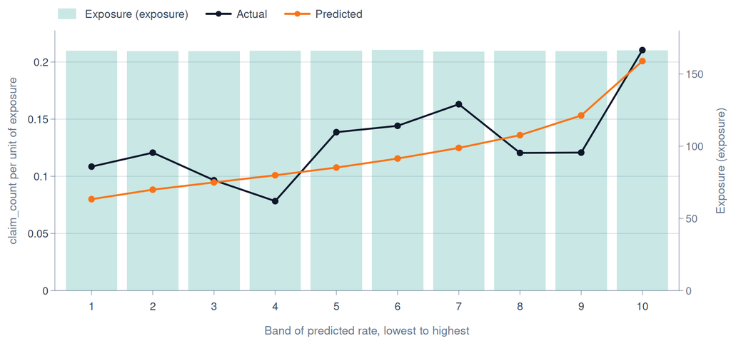

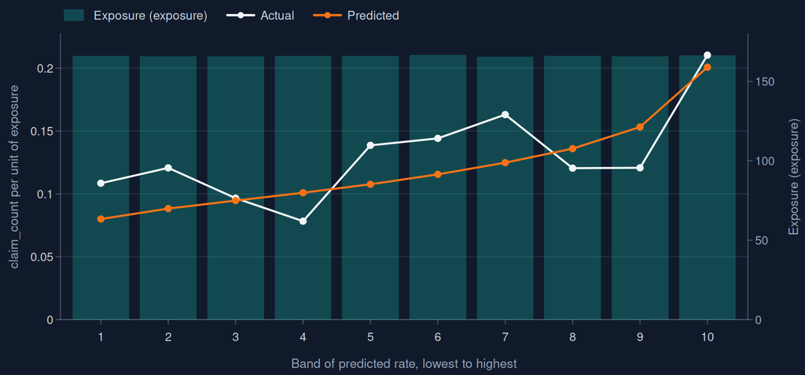

### Lorenz curve

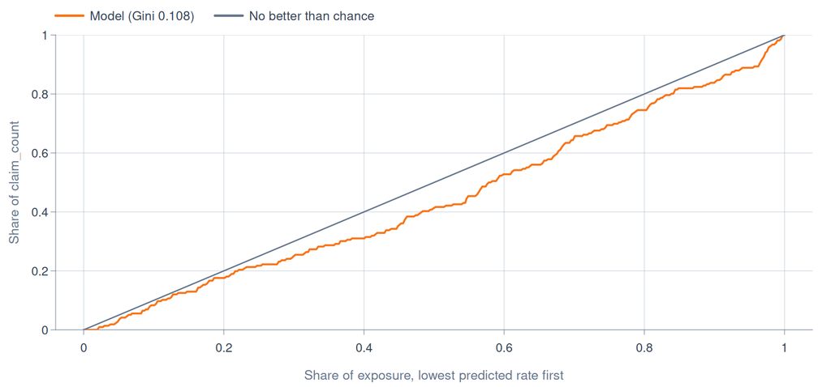

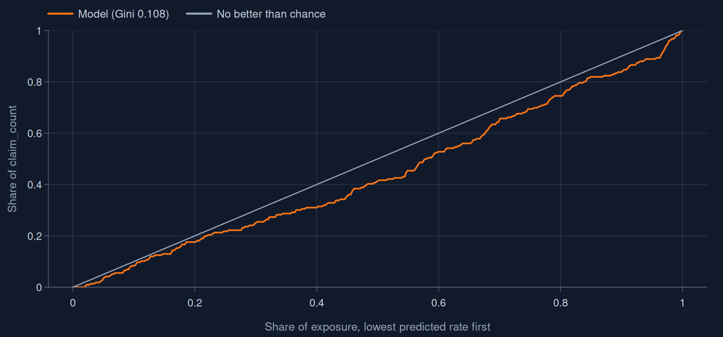

## How to read this report

- The deviance per row measures how far the predictions are from the actual values: on rows held out it shows how the model does on data it has not seen.
- The Gini coefficient measures how well the predictions rank the rows, from 0 (no better than chance) up.
- The rate table gives every prediction as a base rate times a relativity for each rating factor, so a rating engine can price with it.